# Homework 6

your-name-here

## Problem #1: Estimating Quantiles (8 pts; 2pts each)

There are 9 algorithms in R to estimate population quantiles. Type `?quantile` to read about them. Here we will investigate the variance of some of these estimators. To use the quantile function you use the syntax `quantile(vector, probs, type)`. For example if you have data in a vector called `sampleData` and you wish to estimate the 80th percentile using algorithm 7 (the default), you use `quantile(sampleData, .80, type=7)`

Suppose we’re interested in the 95th percentile for $X$, and we know that $X$ follows a uniform distribution. We want to randomly sample $n=30$ values and estimate the 95th percentile. Using MC simulation estimate the following:

1. Which quantile algorithm (4 through 9 has the smallest absolute bias? *Hint: you can use $unif(0,1)$ for the purposes of this estimation, as your answer won’t depend on the upper and lower bounds chosen.*

```r
find_bias <- function(n, type, iter = 1000) {
  biases <- numeric(iter)

  for (i in 1:iter) {
    sampleData <- runif(n, 0, 1)
    est <- quantile(sampleData, 0.95, type = type)
    biases[i] <- abs(est - 0.95)
  }

  return(mean(biases))
}

n <- 30
types_to_test <- 4:9
biases <- sapply(types_to_test, function(type) find_bias(n, type))

names(biases) <- types_to_test
biases
```

```
##          4          5          6          7          8          9
## 0.04159626 0.03272240 0.02733169 0.03915160 0.02981470 0.02987114
```

```r
find_vars <- function(n, type, iter = 1000) {
  ests <- numeric(iter)

  for (i in 1:iter) {
    sampleData <- runif(n, 0, 1)
    ests[i] <- quantile(sampleData, 0.95, type = type)
  }

  return(var(ests))
}

n <- 30
types_to_test <- 4:9
variances <- sapply(types_to_test, function(type) find_vars(n, type))

names(variances) <- types_to_test
variances
```

```
##           4           5           6           7           8           9
## 0.002302397 0.002010895 0.001155089 0.002060561 0.001598639 0.001669188
```

```r
find_bias_norm <- function(n, type, iter = 1000) {
  biases <- numeric(iter)

  for (i in 1:iter) {
    sampleData <- rnorm(n, 0, 1)
    est <- quantile(sampleData, 0.95, type = type)
    biases[i] <- abs(est - 0.95)
  }

  return(mean(biases))
}

find_vars_norm <- function(n, type, iter = 1000) {
  ests <- numeric(iter)

  for (i in 1:iter) {
    sampleData <- rnorm(n, 0, 1)
    ests[i] <- quantile(sampleData, 0.95, type = type)
  }

  return(var(ests))
}

n <- 30
types_to_test <- 4:9
biases <- sapply(types_to_test, function(type) find_bias(n, type))

names(biases) <- types_to_test
biases
```

```
##          4          5          6          7          8          9
## 0.04075054 0.03385609 0.02701758 0.03772496 0.03228516 0.03002015
```

```r
variances <- sapply(types_to_test, function(type) find_vars(n, type))

names(variances) <- types_to_test
variances
```

```
##           4           5           6           7           8           9
## 0.002135384 0.001929312 0.001223716 0.002149575 0.001630867 0.001661622
```

## Problem #2: Estimating a Geometric $p$ (6 pts; 2 pts each)

1. Use the method of moments to come up with an estimator for a geometric distributions parameter $p$. *Hint: Use the fact that if $X\sim Geom(p)$ then $EX=\frac{1-p}{p}$.

```r
estimate_p_geom <- function(sample_data) {
  sample_mean <- mean(sample_data)

  # Estimate p using the method of moments
  p_hat <- 1 / (1 + sample_mean)

  return(p_hat)
}
```

2. Estimate the sampling distribution of this estimator when we sample $n=13$ values from from $Geom(.15)$. Show the histogram of the estimated sampling distribution.

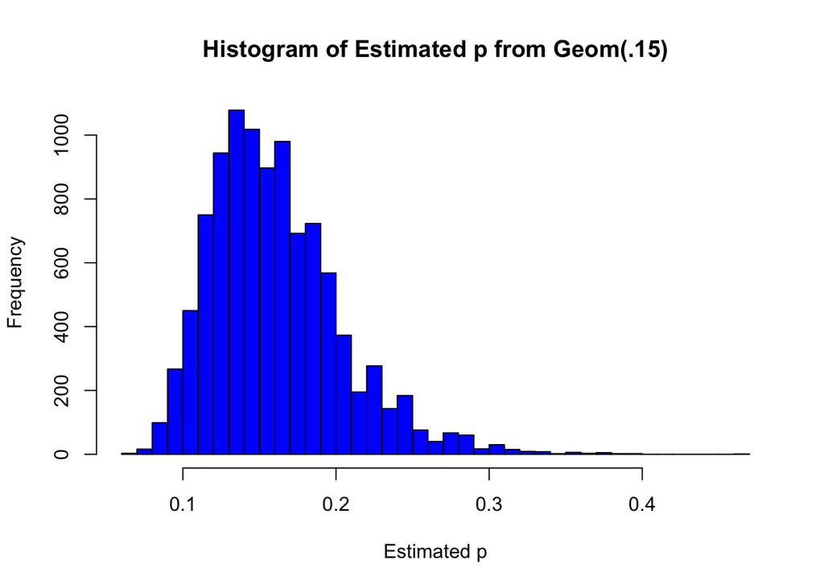

```r
p_hats <- replicate(1e4, estimate_p_geom(rgeom(13, 0.15)))
hist(p_hats, breaks = 50, main="Histogram of Estimated p from Geom(.15)", xlab="Estimated p", col="blue")
```

3. Estimate the bias of this estimator. Is it biased? If it is biased how would you modify it so that you could create an unbiased estimator?

```r
# True value of p
p_true <- 0.15

# Mean of estimated p values
mean_p_hat <- mean(p_hats)

bias <- mean_p_hat - p_true
bias
```

```
## [1] 0.01042193
```

## Problem #3: Estimating $\lambda$ from a Poisson Distribution(8 pts; 2 pts each)

It is interesting that if $X\sim Pois(\lambda)$ that $EX=VarX=\lambda$. One could use either $\bar{X}$ or $S^2$ as an estimator of $\lambda$ perhaps.

1. Using $n=15$ and $\lambda=20$ for this problem, use MC simulation to estimate the sampling distribution of The estimator $\bar{X}$. Show its histogram.

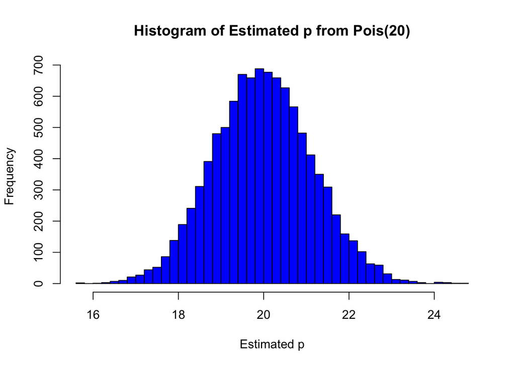

```r
estimate_p_pois <- function(sample_data) {
  return(mean(sample_data))
}

p_hats_pois <- replicate(1e4, estimate_p_pois(rpois(15, 20)))
hist(p_hats_pois, breaks = 50, main="Histogram of Estimated p from Pois(20)", xlab="Estimated p", col="blue")
```

2. Repeat the same but this time use $S^2$.

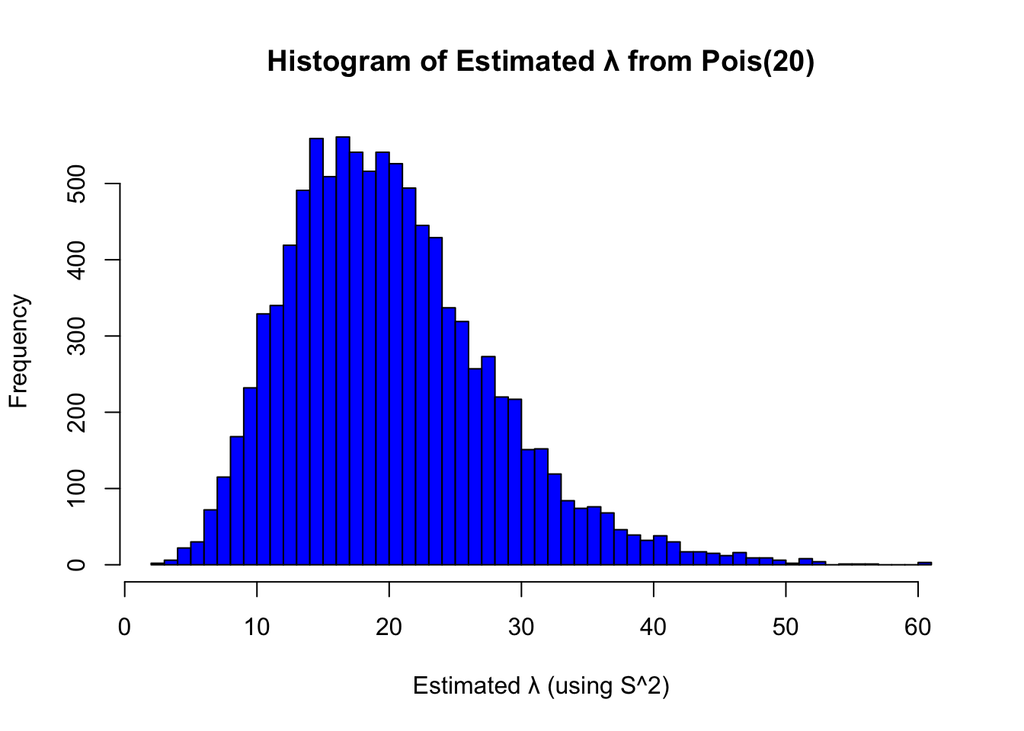

```r
estimate_lambda_pois <- function(sample_data) {
  return(var(sample_data))
}

lambda_hats_pois <- replicate(1e4, estimate_lambda_pois(rpois(15, 20)))
hist(lambda_hats_pois, breaks = 50, main="Histogram of Estimated λ from Pois(20)", xlab="Estimated λ (using S^2)", col="blue")
```

3. Compare the two estimators. Would you prefer one over the other? Why?
- Upon examining the sampling distributions generated from simulations for X_bar and S^2 as estimators of λ in a Poisson distribution, it’s evident that S^2 exhibits a larger right tail. This characteristic indicates increased variability and skewness in the distribution of S^2, suggesting that it might produce more extreme estimates compared to X_bar. On the other hand, X_bar demonstrates a tendency towards smaller variance, implying that its estimates of λ are more concentrated around the true parameter value. Consequently, X_bar emerges as a preferable estimator for λ, primarily due to its enhanced accuracy and reliability. The reduced likelihood of extreme values with X_bar further solidifies its advantage, making it a more robust choice for estimating the parameter of a Poisson distribution.
4. What about a linear combination of the two variables? Could you construct an estimator of $\lambda$ of the form $a\bar{X} + bS^2$ that would be better than using either of them by themselves?
- The new estimator, $\lambda_{new} = a\bar{X} + bS^2$, $a + b = 1$. Minimizing the variance of $\lambda_{new}$ involves finding a and b that minimize $Var(a\bar{X} + bS^2)$. This variance would be affected by both $a\bar{X}$ and $bS^2$, as well as their covariance.

## Problem #4: The Standard Error of $\bar{X}$(8 pts; 2 pts each)

What would be the required sample size $n$ so that the standard error of $\bar{X}$ (i.e. $SD(\bar{X})$) would be 2 (or just under 2) for the following populations:

1. $\text{Normal}(1000, 10^2)$

```r
sigma <- 10  # Population standard deviation
desired_SE <- 2  # Desired standard error of the mean

n_normal <- (sigma / desired_SE)^2
n_normal
```

```
## [1] 25
```

2. $\text{Poisson}(75)$

```r
lambda_poisson <- 75
sigma_poisson <- sqrt(lambda_poisson)
n_poisson <- (sigma_poisson / 2)^2
n_poisson
```

```
## [1] 18.75
```

3. $\text{Binomial}(200, .35)$

```r
p_binomial <- .35
sigma_binomial <- sqrt(200 * p_binomial * (1 - p_binomial))
n_binomial <- (sigma_binomial / 2)^2
n_binomial
```

```
## [1] 11.375
```

4. $\text{Exponential}(.05)$

```r
lambda_exponential <- .05
sigma_exponential <- 1 / lambda_exponential
n_exponential <- (sigma_exponential / 2)^2
n_exponential
```

```
## [1] 100
```